# Chapter Eight: Clustering

Hernan Chavez. 5/7/2021

In the previous notebooks so far, we have seen supervised Machine Learning where the target variable or label is known to us, and we try to predict the output based on the input features. Unsupervised learning is different in a sense that there is no labeled data, and we don't try to predict any output as such; instead we try to find interesting patterns and come up with groups within data. The similar values are grouped together.

When we join a new school or college, we come accross many new faces and everyone looks so different. We hardly know anyone in the institute, and there are no groups in place initally. Slowly and gradually, we start spending time with other people and figure out how similar and dissimilar they are to us. A few months down the line, we are almost settled in our own groups of friends. The friends/members within the group have similar attributes/likings/tastes and hence stay together. Clustering is somewhat similar to this approach of forming groups based on sets of attributes that define the groups.

## Starting with Clustering

We can apply clustering on any sort of data where we want to form groups of similar observations and use it for better decision making. In the early days, customer segmentation used to be done by a **Rule-based approach**, which was much of a manual effort and could only use a limited number of variables. For example,if businesses wanted to do customer segmentation, they would consider up to 10 variables such as age, gender, salary, location, etc., and create rule-based segments that still gave reasonable performance; but in today's scenario tht woud become highly ineffective. One reason is that data availability is in abundance, and the other is the dynamic customer behvior. There are thousands of other variables that can be considered to come up with these machine learning driven segments that are more enriched and meaninful.

When we start clustering, each observation is different and doesnt belong to any group but is based on how similar are the attributes of each observation. We group them in such way that each group contains the most similar records, and there is as much difference as possible between any two groups. So, how do we measure if two observations are similar or different?

There are multiple approcahes to calcular the distance between any two observations. Primarily we represent that any observstion is a form of vector that contains values of that observation(A) as shown below.

| Age | Salary($'000) | Weight (Kgs) | Height (Ft.) |
| --- | --- | --- | --- |
| 32 | 8 | 65 | 6 |

Now, we suppose we want to calculate the distance of this observation/record from any other observtion (B), which also contains similar attributes like those shown below.

| Age | Salary($'000) | Weight (Kgs) | Height (Ft.) |
| --- | --- | --- | --- |
| 40 | 15 | 90 | 5 |

We can measure the distance using the **Euclidean method**, which is strainghtforward.

It is also known as **Cartesian distance**. We are trying to calculate the distance of a straight line between any two points; and if the distance between those points is small, they are more likely to be similar, whereas if the distance is large, they are dissimilar to each other as shown in the figure below.

*Eucliden Distance based Similarity*

[figure not shown]

The Euclidean distance between any two points can be calculated using the formula below:

[figure not shown]

Hence, the Euclidean distance between observations A and B is 27.18. The other techniques to calculate distance between obsercations re the following:

1. Manhattan Distance
2. Mahalonobis Distance
3. Minkowski Distance
4. Chebyshev Distance
5. Cosine Distnce

The aim of clustering is to have minimal intracluster distance and maximum intercluster difference. We can end up with different groups based on the distance approach that we have used to do clustering, and hence it's critical to be sure of opting for the right distance metric that aligns with the business problem. Before going into different clustering techniques, let quickly go over some of the applications of clustering.

## Applications

Clustering is used in a variety of user cases these days ranging from customer segmentation to anomaly detection. Business widely use machine learning driven clustering for profiling customer and segmentation to create market strategies around these results. Clustering drives a lot of search engines' results by finding similar objects in one cluster and dissimilar objects fsr from each other. It recommends the nearest similar result based on a search query.

Clustering can be done in multiple ways based on the type of data and business requirement. The most used ones are the K-means and Hierarchical Clustering.

## K-Means

'K' stands for a number of clusters or groups that we want to form in the given dataset. This type of clustering involves deciding the number of clusters in advance. Before looking at how K-means clustering works, let's get familiar with a couple of terms first.

1. Centroid
2. Variance

**Centroid** refers to the center datapoint at the center of a cluster or a group. It is also the most representative point within the cluster as it's the utmost equidistant datapoint from the other points within the cluster. The **centroid** (represented by a cross) for three random clusters is shown in the figure below.

*Centroids of clusters*

[figure not shown]

Each cluster or group contains different number of data points that are nearest to the centroid of the cluster.Once the individual datapoints change clusters, the centroid value of the cluster also changes. The center position within a group is altered, resulting in a new centroid as shown in the figure below.

*New Centroids of new clusters*

[figure not shown]

The whole idea of clustering is to minimize intracluster distance, that is, the internal distance of data points from the centroid of cluster and maximize the intercluster distance, that is, between the centroids of two different clusters.

**Variance** is the total sum of intracluster distances between centroid and data points within that cluster is shown in the figure below. The variance keeps on decreasing with an increase in the number of clusters. The more clusters, the less the number of data points within each cluster and hence less variability.

*Intracluster Distance*

[figure not shown]

**K-means** clustering is composed of four steps in total to form the integral groups within the dataset. We will consider a sample dataset to understand how **K-means** clustering algorithm works. The dataset contains a few users with their age and weight values as shown in the table below. Now we will ue **K-means** clustering to come up with meaningul clusters and understand the algorithm.

*Sample Dataset for K-Means*

| User ID | Age | Weight |
| --- | --- | --- |
| 1 | 18 | 80 |
| 2 | 40 | 60 |
| 3 | 35 | 100 |
| 4 | 20 | 45 |
| 5 | 45 | 120 |
| 6 | 32 | 65 |
| 7 | 17 | 50 |
| 8 | 55 | 55 |
| 9 | 60 | 90 |
| 10 | 90 | 50 |

If we plot these users in a two-dimensional spacem we can see that no point belongs to any group initally, and our itention is to find clusters (we can try with two or three) within this group of users such that each group contains similar users. Each user is represented by the age and weight as shown in the figure below.

*Users before clustering*

[figure not shown]

### Step 1: Decide K

It starts with deciding the number of clusters (K). Most of the time, we are not sure of the right number of groups at the start, but we can find the best number of clusters using method called the **Elbow method** based on variability. For this example, let's start with K=2 to keep things simple. So, we are looking for two clusters within this sample data.

### Step 2: Random Initialization of Centroids

The next step is to randomly consider any two of the points to be a centroid of new clusters. These can be chosen randomly, so we select user number 5 and user number 10 as the two centroids on the new clusters as shown in the table below.

*Sample Dataset for K-Means*

| User ID | Age | Weight |
| --- | --- | --- |
| 1 | 18 | 80 |
| 2 | 40 | 60 |
| 3 | 35 | 100 |
| 4 | 20 | 45 |
| 5 (centroid 1) | 45 | 120 |
| 6 | 32 | 65 |
| 7 | 17 | 50 |
| 8 | 55 | 55 |
| 9 | 60 | 90 |
| 10 (centroid 2) | 90 | 50 |

The centroids can be represented by weight and age values as shown in the figure below.

*Random Centroids of two clusters*

[figure not shown]

### Step 3: Assigning Cluster Number to each Value

In this step, we calculate the distance of each point from the centroid. In this example, we calculate the **Euclidean squared distance** of each user from the two centroid points. based onnthe distance value, we go ahead and decide which particular cluster the user belongs to (1 or 2). Whichever centroid the user is near to (less distance) would become part of that cluster. The **Euclidean squared distance** is calculated fro each user shown in the table below. The distance of user 5 and user 10 would be zero from respective centroids an they are the same points as centroids.

*Cluster Assiignment Based on Distance from Centroids*

[figure not shown]

So, as per the distance from centroids, we have allocated each user to either Cluster 1 or Cluster 2. Cluster 1 contains five users and Cluster 2 also contains five users. The initial clusters as shown in the figure below.

*Initial Cluster and Centroids*

[figure not shown]

As discussed earlier, the centroids of the clusters are bound to change after inclusion or exclusion of new data points in the cluster. As the earlier centroids (C1, C2) are no longer at the center of clusters, we need to claculate new centroids in the next step.

### Step 4: Claculate New Centroids and Reassign Clusters

The final step in K-means clustering is to calculate the new centroids of clusters and reassign the clusters to each value based on the distance from new centroids. Let's calculate the new centroid of Cluster 1 and Cluster 2. To calculate the centroid of Cluster 1, we simply take the mean of age and weight for only those values that belong to Cluster 1 as shown in the table below.

*New Centroid Calculation of Cluster 1*

[figure not shown]

The centroid calculation for Cluster 2 is also done in a similar manner and shown in the table below.

*New Centroid Calculation of Cluster 2*

[figure not shown]

Now we have new centroid values for each cluster represented by a cross in figure below. The arrow signifies the movement of the centroid within the cluster.

*New Centroids of both clusters*

[figure not shown]

With centroids of each clusterm we repeat step 3 for calculating the **Euclidean suqred distance** of each user from new centroids and find out the nearest centroid. We then reassign the users to either Cluster 1 or Cluster 2 based on the distance from the centroid. In this case, only one value (user 6) changes from cluster 1 to 2 as shown in the table below.

*Rellocation of Clusters*

[figure not shown]

Now, Cluster 1 is left with only four users and Cluster 2 contains siz users based on the distance from each cluster's centroid as shown in the figure below.

*Rellocation of clusters*

[figure not shown]

We keep repeating the above steps until there is no more change in cluster allocations. The centroids of new clusters are shown in the table below.

*Calculation of Centroids*

[figure not shown]

As we go through the steps, the centroid movements keep becoming small, and the values almost become part of a particular cluster as shown in the figure below.

*Rellocation of clusters*

[figure not shown]

As we can observe, there is no more change in the points after the change in crentroids, which comoletes the **K-means** clustering. The results can vary as it's based on the first set of random centroids. To reproduce the results, we can set that starting point ourselves as well. The final clusters with values are shown in the figure below.

[figure not shown]

*Final Clusters*

[figure not shown]

Cluster 1 contains the users that are average on age attribute but seem to be very high on the weight variable whereas Cluster 2 seems to be grouping those users together who are older than average but very conscious of their weight as shown in the figure below.

*Attributes of final clusters*

[figure not shown]

## Deciding on the Number of Clusters (K)

Selecting an optimal number of clusters is quite tricky most of the time as we need a deep understanding of the dataset and the context of the business problem. Additionally there is no right or wrong answer when it comes to unsupervised learning. One approach might result in a different number of clusters compared to another approach. We have to try and figure out which approach works the best and if the clusters created are relevant enough for decision making. Each cluster an be represented with a few important attributes that signify or give information about a partiular cluster. However, there is method to pick the possible number of clusters with a dataset. This method is known as the **elbow method**.

The **elbow method** helps us to measure the total variance in the data with a number of clusters. The higher the number of clusters, the less the variance would become, If we have an equal number of clusters to the number of records in a dataset, then the variability would be zero because the distance of each point from itself is zero. The variability or **SSE (Sumof Squared Errors)** along with "K" values is shown in the figure below.

*Elbow Method*

[figure not shown]

## Hierarchical Clustering

This is another type of unsupervised machine learning technique and is different from K-means in the sense that we don't have to know the number of clusters in advance. There are two types of **Hierarchical clustering**.

1. Agglomerative Clustering (Bottom-Up Approach)
2. Divisive Clustering (Top-Down Approach)

We'll discuss **agglomerative clustering** as it is the main type. This starts with the assumption that each data point is a separate cluster and gradually keeps combining the nearest values into the same cluster unitl all the values become part of one cluster. This is a bottom-up approach that calculates the distance between each cluster and merges the two closest into one. Let's uunderstand the agglomerative clustering eith the help of visualization. Let's say we have seven data points initally (A1-A7), and they need to be grouped into clusters that contain similar values together using **agglomerative clustering** as shown in the figure below.

*Each value as individual cluster*

[figure not shown]

At the initial stage (step 1), each point is treated as an individual cluster. In the next step, the distance between every point is calculated and the nearest points are combined together into a single cluster. In this example, A1 and A2, A5 and A6 are nearest to each other and hence form a single cluster as shown in the figure below.

*Nearest cluster merged together*

[figure not shown]

Deciding the most optimal number of clusters while using **Hierarchical clustering** can be done in multiple ways. One way is to use the **elbow method** itself and the other option is by making use of something known as **Dendrogram**. it is used to visualize the variability between clusters (**Euclidean distnce**). In a **Dendrogram**, the height of the verticla lines represents the distance between points or clusters and data points listed along the bottom. Each point is plotted on the X-axis and the distance is represented on the Y-axis (length). It is **hierarchical representation** of the data points. In this example, the **Dendrogram** at step 2 looks like the one shown in the figure below.

*Dendrogram*

[figure not shown]

In step 3, the exercise of calculating the distance between clusters is repeated and the nearest clusters are combined into a single cluster. This time A3 gets merged with (A1, A2) and A4 with (A5, A6) as shown in the figure below.

*Nearest clusters merged together*

[figure not shown]

The **Dendrogram** after step 3 is hsown in the figure below.

*Dendrogram post step 3*

[figure not shown]

In step 4, the distance between the only remaining point A7 gets calculated and found nearer to cluster (A4, A5, A6). It is merged with the same cluster as shown in the figure below.

*Cluster formation*

[figure not shown]

At the last stage (step 5), all the points get combined into a single Cluster (A1, A2, A3, A4, A5, A6, A7) as shown in the figure below.

*Agglomerative clustering*

[figure not shown]

Sometimes it is difficult tomidentify the right number of clusters by the **Dendrogram** as it can become very complicted and difficult to interpret depending on the dataset being used to do clustering. The **Hierarchical clustering** doesn't work well on large datasets compared to **K-means**. Clustering is also very sensitive to the scale of data points, so it's always advised to do data scaling before clustering. There are other types of clustering that can be used to group the similar data points together such as the following:

1. Gaussian Mixture Model Clustering
2. Fuzzy C-Means Clustering

But the above methods are beyond the scope of this notebook. We now jump into using a dataset for building clusters using **K-means** in PySpark.

## Code

This section of the notebook covers **K-Means clustering** using PySpark and Jupyter Notebook.

For this exercise, we consider the most standardized open sourced dataset out there - an IRIS dataset to capture the cluster number and compare supervised and unsupervised performance.

## Data Info

The dataset that we are going to use for this notebook is the famous open sourced IRIS dataset and contains a total of 150 records with 5 columns (sepal lenght, sepal width, petal length, petal width, species). There are 50 records for each type of species. We will try to group these into clusters without using the species label information.

## Step 1: Create the SparkSession Object

We start Jupyter Notebook and import SparkSession and create a new SparkSession object to use Spark:

```python
from pyspark.sql import SparkSession
spark = SparkSession.builder.appName('K_means').getOrCreate()
```

## Step 2: Read the Dataset

We then load and read the dataset within Spark using a dataframe. We have to make sure we have opened PySpark from the same directory folder where the dataset is available or else we have to mention the directory path of the data folder.

```python
import numpy as np
import pandas as pd
from pyspark.sql.types import StringType, DoubleType
from pyspark.sql.functions import udf
from pyspark.sql.functions import pandas_udf

# File location and type
file_location = "Material/iris_dataset.csv"
file_type = "csv"

# CSV options
infer_schema = "True"
first_row_is_header = "True"
delimiter = ","

# The applied options are for CSV files. For other file types, these will be ignored.
# For a tab separated file, we need to pass an additional argument while reading the file to specifiy the separator (sep='\t').
# Setting the argument inferSchema to true indicates that Spark in the background will infer the datatypes of the values in the dataset on its own.
df = spark.read.format(file_type) \
  .option("inferSchema", infer_schema) \
  .option("header", first_row_is_header) \
  .option("sep", delimiter) \
  .load(file_location)

df.show(40)
```

```
+------------+-----------+------------+-----------+-------+
|sepal_length|sepal_width|petal_length|petal_width|species|
+------------+-----------+------------+-----------+-------+
|         5.1|        3.5|         1.4|        0.2| setosa|
|         4.9|        3.0|         1.4|        0.2| setosa|
|         4.7|        3.2|         1.3|        0.2| setosa|
|         4.6|        3.1|         1.5|        0.2| setosa|
|         5.0|        3.6|         1.4|        0.2| setosa|
|         5.4|        3.9|         1.7|        0.4| setosa|
|         4.6|        3.4|         1.4|        0.3| setosa|
|         5.0|        3.4|         1.5|        0.2| setosa|
|         4.4|        2.9|         1.4|        0.2| setosa|
|         4.9|        3.1|         1.5|        0.1| setosa|
|         5.4|        3.7|         1.5|        0.2| setosa|
|         4.8|        3.4|         1.6|        0.2| setosa|
|         4.8|        3.0|         1.4|        0.1| setosa|
|         4.3|        3.0|         1.1|        0.1| setosa|
|         5.8|        4.0|         1.2|        0.2| setosa|
|         5.7|        4.4|         1.5|        0.4| setosa|
|         5.4|        3.9|         1.3|        0.4| setosa|
|         5.1|        3.5|         1.4|        0.3| setosa|
|         5.7|        3.8|         1.7|        0.3| setosa|
|         5.1|        3.8|         1.5|        0.3| setosa|
|         5.4|        3.4|         1.7|        0.2| setosa|
|         5.1|        3.7|         1.5|        0.4| setosa|
|         4.6|        3.6|         1.0|        0.2| setosa|
|         5.1|        3.3|         1.7|        0.5| setosa|
|         4.8|        3.4|         1.9|        0.2| setosa|
|         5.0|        3.0|         1.6|        0.2| setosa|
|         5.0|        3.4|         1.6|        0.4| setosa|
|         5.2|        3.5|         1.5|        0.2| setosa|
|         5.2|        3.4|         1.4|        0.2| setosa|
|         4.7|        3.2|         1.6|        0.2| setosa|
|         4.8|        3.1|         1.6|        0.2| setosa|
|         5.4|        3.4|         1.5|        0.4| setosa|
|         5.2|        4.1|         1.5|        0.1| setosa|
|         5.5|        4.2|         1.4|        0.2| setosa|
|         4.9|        3.1|         1.5|        0.1| setosa|
|         5.0|        3.2|         1.2|        0.2| setosa|
|         5.5|        3.5|         1.3|        0.2| setosa|
|         4.9|        3.1|         1.5|        0.1| setosa|
|         4.4|        3.0|         1.3|        0.2| setosa|
|         5.1|        3.4|         1.5|        0.2| setosa|
+------------+-----------+------------+-----------+-------+
only showing top 40 rows
```

## Step 3: Exploratory Data Analysis

In this section, we explore the dataset by vieweing it and validating its shape.

```python
print((df.count(), len(df.columns)))
```

```
(150, 5)
```

So, the above output confirms the size of our dataset and we can then validate the datatypes of the input values to check if we need to change/cast any columns' datatypes.

```python
df.printSchema()
```

```
root
 |-- sepal_length: double (nullable = true)
 |-- sepal_width: double (nullable = true)
 |-- petal_length: double (nullable = true)
 |-- petal_width: double (nullable = true)
 |-- species: string (nullable = true)
```

There is a total of five columns out of which four are numerical and the label column is categorical.

```python
from pyspark.sql.functions import rand

df.orderBy(rand()).show(10, False)
```

```
+------------+-----------+------------+-----------+----------+
|sepal_length|sepal_width|petal_length|petal_width|species   |
+------------+-----------+------------+-----------+----------+
|6.6         |2.9        |4.6         |1.3        |versicolor|
|6.3         |3.3        |6.0         |2.5        |virginica |
|5.8         |2.7        |5.1         |1.9        |virginica |
|5.5         |2.6        |4.4         |1.2        |versicolor|
|5.6         |3.0        |4.5         |1.5        |versicolor|
|6.4         |3.2        |4.5         |1.5        |versicolor|
|4.8         |3.4        |1.9         |0.2        |setosa    |
|5.0         |3.4        |1.5         |0.2        |setosa    |
|7.6         |3.0        |6.6         |2.1        |virginica |
|5.2         |3.5        |1.5         |0.2        |setosa    |
+------------+-----------+------------+-----------+----------+
only showing top 10 rows
```

```python
df.groupBy('species').count().orderBy('count').show(10, False)
```

```
+----------+-----+
|species   |count|
+----------+-----+
|virginica |50   |
|versicolor|50   |
|setosa    |50   |
+----------+-----+
```

So, it confirms that there are an equal number of records for each species available in the dataset.

## Step 4: Feature Engineering

This is the part where we create a single vector combining all input features by using Spark's VectorAssembler. It creates only a single feature that captures the input values for a particular row. So, instead of four input columns (we are not considering a label column since it's an unsurpervised machine learning tecnique), it esentially translates it into a single column with four input values in the form of a list.

```python
from pyspark.ml.linalg import Vector

from pyspark.ml.feature import VectorAssembler

input_cols = ['sepal_length', 'sepal_width', 'petal_length', 'petal_width']

vec_assembler = VectorAssembler(inputCols = input_cols, outputCol = 'features')

final_data = vec_assembler.transform(df)
```

## Step 5: Build K-Means Clustering Model

The final data contains the input vector that can be used to run **K-means clustering**. Since we need to declare the value of "K" in advance before uisng **K-means**, we can use **elbow method** to figure out the right value of "K". In order to use the **elbow method**, we run the **K-means clustering** for different values of "K". First, we import **K-means** from the PySpark library and create an empty list that would capture the variability or SSE (within cluster distance) for each value of K.

```python
from pyspark.ml.clustering import KMeans

errors = []

for k in range(2,10):
  kmeans = KMeans(featuresCol = 'features', k=k)
  model = kmeans.fit(final_data)
  intra_distance = model.computeCost(final_data)
  errors.append(intra_distance)

errors = [round(float(elem),2) for elem in errors]

print(errors)
```

```
[152.37, 78.94, 57.44, 46.54, 47.64, 35.38, 39.19, 28.39]
```

**The 'K' should have a minimum value of 2 to be able to build clusters.**

Now, we can plot the intracluster distance with the number of clusters uisng numpy and matplotlib.

```python
import pandas as pd

import numpy as np

import matplotlib.pyplot as plt

cluster_number = list(range(2,10))

fig1 = plt.figure()

plt.xlabel('Number of Clusters (K)')

plt.ylabel('SSE')

plt.scatter(cluster_number, errors, s=20, c='r', alpha=0.5)
```

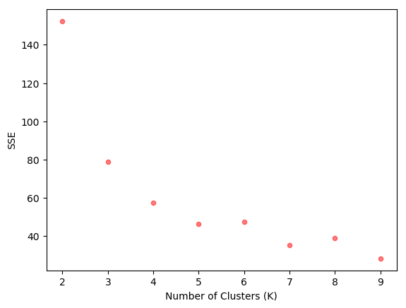

```python
fig1
```

In this case, k=3 seems to be the best number of clusters as we can see a sort of **elbow formation between three and four values**. We build final clusters using k = 3.

```python
kmeans = KMeans(featuresCol = 'features', k = 3)
model = kmeans.fit(final_data)
model.transform(final_data).groupBy('prediction').count().show()
```

```
+----------+-----+
|prediction|count|
+----------+-----+
|         1|   38|
|         2|   62|
|         0|   50|
+----------+-----+
```

**K-Means clustering** gives us three different clusters based on the IRIS dataset. We certainly are making a few of the allocations wrong as only one category has 50 records in the group, and the rest of the categories are mixed up. We can use the transform function to assign the cluster number to the original dataset and use a groupBy function to validate the groupings.

```python
predictions = model.transform(final_data)

predictions.groupBy('species', 'prediction').count().show()
```

```
+----------+----------+-----+
|   species|prediction|count|
+----------+----------+-----+
| virginica|         2|   14|
|    setosa|         0|   50|
| virginica|         1|   36|
|versicolor|         1|    2|
|versicolor|         2|   48|
+----------+----------+-----+
```

As it can be observed, the setosa species is pefectly grouped along with versicolor, almost being captured in the same cluster, but verginica seems to fall within two different groups. **K-means** can produce different results every time as it chooses a starting point **(centroid) randomly every time**. Hence, the results that you might get in your **K-means clustering** might be totally different from these results unless we use a seed to reproduce the results. The seed ensures the split and the initial centroid values remain consistent throughout the analysis.

## Step 6: Visualization of Clusters

In the final step, we can visualize the new clusters with the help of Python's matplotlib library. In order to do that, we convert our Spark dataframe to Pandas dataframe first.

```python
predictions.orderBy(rand()).show()

# Enable Arrow-based columnar data transfers
#spark.conf.set("spark.sql.execution.arrow.enabled", "true")

# Convert the Spark DataFrame back to a pandas DataFrame using Arrow
pandas_df = predictions.toPandas()

pandas_df.head()
```

```
+------------+-----------+------------+-----------+----------+-----------------+----------+
|sepal_length|sepal_width|petal_length|petal_width|   species|         features|prediction|
+------------+-----------+------------+-----------+----------+-----------------+----------+
|         5.6|        3.0|         4.1|        1.3|versicolor|[5.6,3.0,4.1,1.3]|         2|
|         4.4|        2.9|         1.4|        0.2|    setosa|[4.4,2.9,1.4,0.2]|         0|
|         5.6|        3.0|         4.5|        1.5|versicolor|[5.6,3.0,4.5,1.5]|         2|
|         4.3|        3.0|         1.1|        0.1|    setosa|[4.3,3.0,1.1,0.1]|         0|
|         4.9|        2.4|         3.3|        1.0|versicolor|[4.9,2.4,3.3,1.0]|         2|
|         4.8|        3.4|         1.6|        0.2|    setosa|[4.8,3.4,1.6,0.2]|         0|
|         4.8|        3.4|         1.9|        0.2|    setosa|[4.8,3.4,1.9,0.2]|         0|
|         5.6|        2.8|         4.9|        2.0| virginica|[5.6,2.8,4.9,2.0]|         2|
|         5.8|        2.7|         3.9|        1.2|versicolor|[5.8,2.7,3.9,1.2]|         2|
|         5.4|        3.0|         4.5|        1.5|versicolor|[5.4,3.0,4.5,1.5]|         2|
|         5.9|        3.0|         5.1|        1.8| virginica|[5.9,3.0,5.1,1.8]|         2|
|         6.4|        2.8|         5.6|        2.1| virginica|[6.4,2.8,5.6,2.1]|         1|
|         6.8|        3.0|         5.5|        2.1| virginica|[6.8,3.0,5.5,2.1]|         1|
|         6.0|        2.7|         5.1|        1.6|versicolor|[6.0,2.7,5.1,1.6]|         2|
|         6.7|        3.0|         5.2|        2.3| virginica|[6.7,3.0,5.2,2.3]|         1|
|         6.4|        3.1|         5.5|        1.8| virginica|[6.4,3.1,5.5,1.8]|         1|
|         7.2|        3.2|         6.0|        1.8| virginica|[7.2,3.2,6.0,1.8]|         1|
|         5.7|        3.8|         1.7|        0.3|    setosa|[5.7,3.8,1.7,0.3]|         0|
|         5.5|        2.5|         4.0|        1.3|versicolor|[5.5,2.5,4.0,1.3]|         2|
|         5.5|        3.5|         1.3|        0.2|    setosa|[5.5,3.5,1.3,0.2]|         0|
+------------+-----------+------------+-----------+----------+-----------------+----------+
only showing top 20 rows
```

|  | sepal_length | sepal_width | petal_length | petal_width | species | features | prediction |
| --- | --- | --- | --- | --- | --- | --- | --- |
| 0 | 5.1 | 3.5 | 1.4 | 0.2 | setosa | [5.1, 3.5, 1.4, 0.2] | 0 |
| 1 | 4.9 | 3.0 | 1.4 | 0.2 | setosa | [4.9, 3.0, 1.4, 0.2] | 0 |
| 2 | 4.7 | 3.2 | 1.3 | 0.2 | setosa | [4.7, 3.2, 1.3, 0.2] | 0 |
| 3 | 4.6 | 3.1 | 1.5 | 0.2 | setosa | [4.6, 3.1, 1.5, 0.2] | 0 |
| 4 | 5.0 | 3.6 | 1.4 | 0.2 | setosa | [5.0, 3.6, 1.4, 0.2] | 0 |

We import the required libraries to plot the third visualization and observe the clusters.

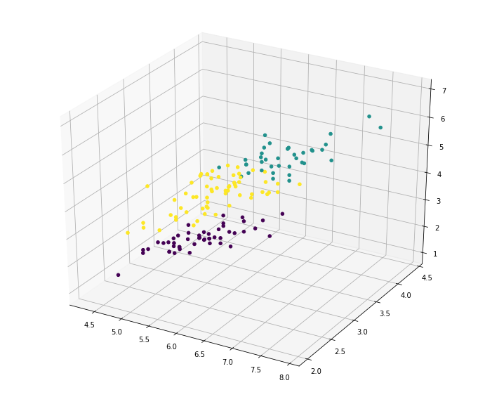

```python
from mpl_toolkits.mplot3d import Axes3D

cluster_vis = plt.figure(figsize=(12,10)).gca(projection='3d')

cluster_vis.scatter(pandas_df.sepal_length, pandas_df.sepal_width, pandas_df.petal_length, c=pandas_df.prediction, depthshade = False)

plt.show()
```

## Conclusion

In this notebook, we went over different types of unsupervised machine learning techniques and also built clusters using **K-Means** algorithms in PySpark. **K-Means** groups the dta points using random centroid initialization whereas **Hierarchical clustering** focuses on merging entire datapoints into a single cluster. We also covered various techniques to decide the optimal number of clusters like the **Elbow method** and **Dendrogram**, which use variance optimization while grouping the data points.

Reference: Singh, P., & Singh. (2004). Machine Learning with PySpark. Apress.